# RCA Analysis

2023-08-29

## Congenital RCA Anomalous Coronaries

Here we analyse the age/sex matched controls with the 187 cases provided. We remove select cases and produce three compariosns:

- Treated versus untreated RCA cases have no difference in mortality
- When comparing among unroofing, CABG, cath or no treatment, no differences in mortality
- when comparing to healthy age and sex matched controls no difference

Now let’s answer our questions:

#1) survival between surgical unroofing or reimplantation vs. cabg vs. cath vs. no intervention.

First, check if any intervention is useful:

```
## Call: survfit(formula = Surv(time = censor.age, event = death) ~ intervention,
##     data = ada)
##
##                  n events median 0.95LCL 0.95UCL
## intervention=0 132     32   85.0    81.9    92.9
## intervention=1  56     10   89.8    82.2      NA
```

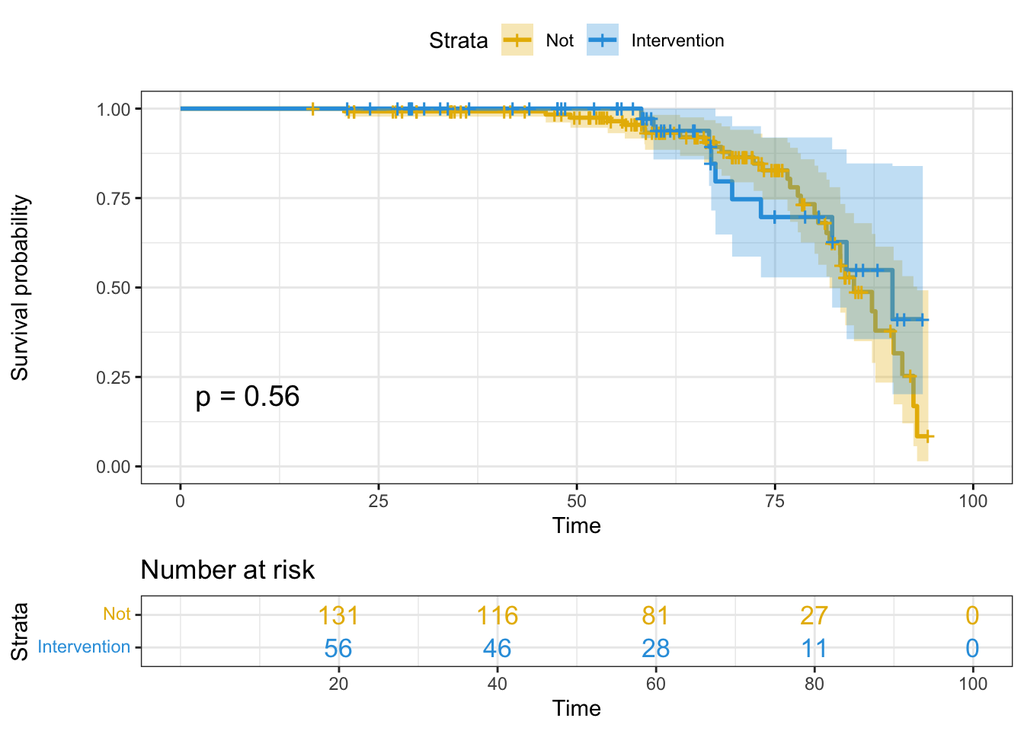

### Now let’s do for the different types of intervention versus none:

```
## Call: survfit(formula = Surv(time = censor.age, event = death) ~ treat,
##     data = ada)
##
##                           n events median 0.95LCL 0.95UCL
## treat=unroofing_implant  33      1     NA    67.5      NA
## treat=bypass             17      7   89.8    73.2      NA
## treat=cath                5      2   84.0      NA      NA
## treat=none              132     32   85.0    81.9    92.9
```

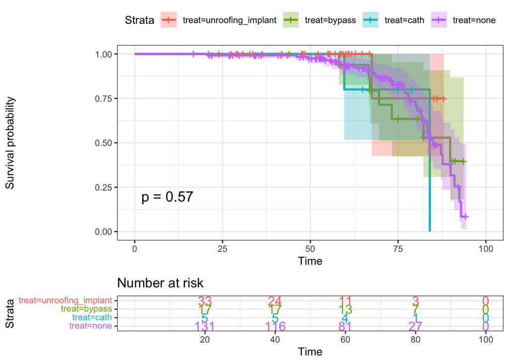

However, when we break by intervention, we see that there is a difference among the 4 categories of patients:

```
## # A tibble: 4 × 8
##   treat             Per_female hyperlip stroke    dm smoke  race birthyear
##   <fct>                  <dbl>    <dbl>  <dbl> <dbl> <dbl> <dbl>     <dbl>
## 1 unroofing_implant      0.364    0.424 0.0303 0.121 0.242 0.727     1971.
## 2 bypass                 0.294    0.706 0.0588 0.353 0.353 0.706     1946.
## 3 cath                   0.2      0.8   0      0     0.4   0.6       1948.
## 4 none                   0.371    0.5   0.0303 0.197 0.348 0.720     1956.
```

### Now:

And then a comparison of the low surgical risk (who do not have slit-like, and do not have intramural course) vs healthy controls?

```
##
## Call:
## matchit(formula = case_control ~ age.today + sex, data = df,
##     method = NULL, distance = "glm")
##
## Summary of Balance for All Data:
##           Means Treated Means Control Std. Mean Diff. Var. Ratio eCDF Mean
## distance         0.0035        0.0029          0.4406     0.9462    0.1325
## age.today       65.4743       60.5587          0.2423     1.3443    0.0704
## sex              0.3583        0.5552         -0.4108          .    0.1970
##           eCDF Max
## distance    0.2714
## age.today   0.1435
## sex         0.1970
##
## Sample Sizes:
##           Control Treated
## All         63521     187
## Matched     63521     187
## Unmatched       0       0
## Discarded       0       0
```

## Now do nearest neighbor propensity score matching:

Here we display info about the matching after controlling for DOB, sex matching all those in the RCA group (both treated and untreated) with health controls:

```
## A matchit object
##  - method: 1:1 nearest neighbor matching without replacement
##  - distance: Propensity score
##              - estimated with logistic regression
##  - number of obs.: 63708 (original), 374 (matched)
##  - target estimand: ATT
##  - covariates: age.today, sex
```

```
##
## Call:
## matchit(formula = case_control ~ age.today + sex, data = df,
##     method = "nearest", distance = "glm")
##
## Summary of Balance for Matched Data:
##           Means Treated Means Control Std. Mean Diff. Var. Ratio eCDF Mean
## distance         0.0035        0.0035          0.0005     1.0029    0.0000
## age.today       65.4743       64.6153          0.0423     1.2833    0.0237
## sex              0.3583        0.3422          0.0335          .    0.0160
##           eCDF Max Std. Pair Dist.
## distance    0.0053          0.0005
## age.today   0.0588          0.3508
## sex         0.0160          0.2788
##
## Sample Sizes:
##           Control Treated
## All         63521     187
## Matched       187     187
## Unmatched   63334       0
## Discarded       0       0
```

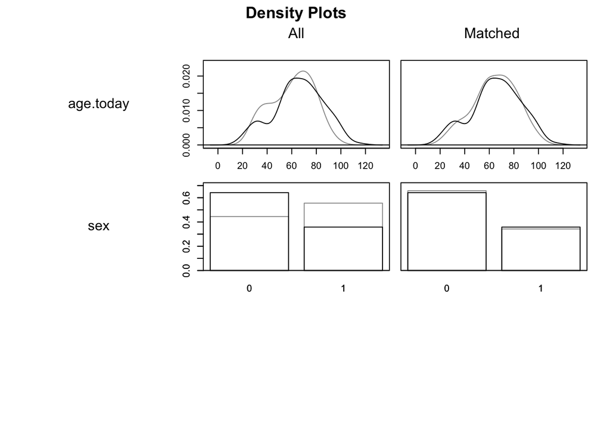

Now let’s generate the survival model:

```
## Call: survfit(formula = Surv(time = censor.age, event = death) ~ intervention,
##     data = m)
##
##                          n events median 0.95LCL 0.95UCL
## intervention=untreated 132     32   85.0    81.9    92.9
## intervention=treated    55     10   89.8    82.2      NA
## intervention=control   187     22   90.7    87.7      NA
```

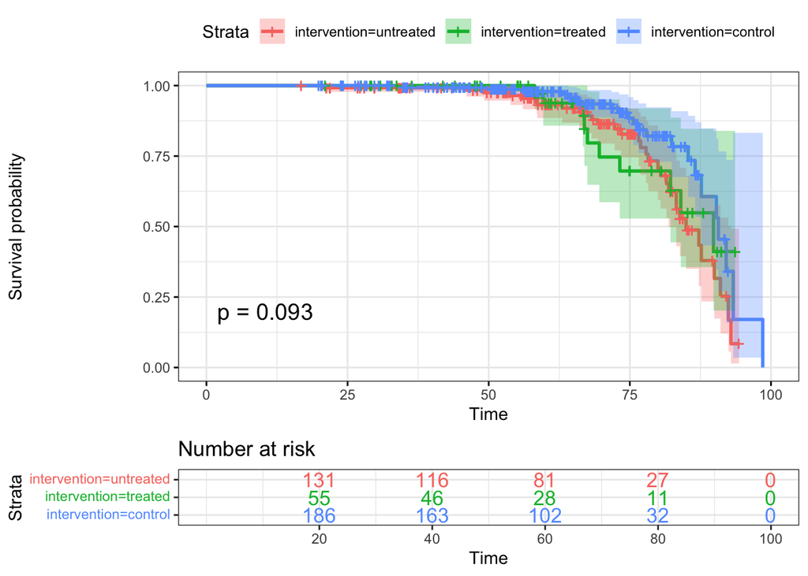